```r
library('ggplot2') # visualization
library('ggthemes') # visualization
library('scales') # visualization
library('grid') # visualisation
library('gridExtra') # visualisation
library('corrplot') # visualisation
library('ggfortify') # visualisation
library('dplyr') # data manipulation
library('readr') # data input
library('tibble') # data wrangling
library('stringr') # string manipulation
library('forcats') # factor manipulation
library('mclust') # clustering
library(data.table)
library(caret)
```

# DATA CLEANING PHASE

```r
raw_train <- fread("C:/Users/betha/Desktop/EXST_7152/Group_Project/train.csv")
raw_test <- fread("C:/Users/betha/Desktop/EXST_7152/Group_Project/test.csv")
```

```r
train_count <- nrow(raw_train)
raw_train[,ID:= NULL] #drop training ID


raw_test[,ID:= NULL] #dropping test ID
raw_test<- cbind(y=0, raw_test)
test_count <- nrow(raw_test)
```

```r
#Combine the two datasets for feature engineering

full <- rbind(raw_train,raw_test)
```

```r
#Convert Everything to factors so that we have names of each variable

variable_integer_list <- names(sapply(full, is.integer))
variable_character_list <- names(sapply(full, is.character))

full[,variable_integer_list] <- lapply(full[,variable_integer_list, with=FALSE],factor)
full[,variable_character_list] <- lapply(full[,variable_character_list, with=FALSE],factor)
```

```r
#y as numeric
full$y <- as.numeric(as.character(full$y))
```

```r
#removing variables without any variance

zerovariance_variables <- nearZeroVar(full, names=TRUE)
zerovariance_variables
```

1. 'X4'

2. 'X10'

3. 'X11'

4. 'X15'

5. 'X16'

6. 'X17'

7. 'X18'

8. 'X21'

9. 'X23'

10. 'X24'

11. 'X26'

12. 'X28'

13. 'X29'

14. 'X30'

15. 'X32'

16. 'X33'

17. 'X34'

18. 'X36'

19. 'X38'

20. 'X39'

21. 'X40'

22. 'X41'

23. 'X42'

24. 'X44'

25. 'X47'

26. 'X48'

27. 'X52'

28. 'X53'

29. 'X54'

30. 'X55'

31. 'X56'

32. 'X57'

33. 'X59'

34. 'X60'

35. 'X61'

36. 'X62'

37. 'X63'

38. 'X65'

39. 'X66'

40. 'X67'

41. 'X69'

42. 'X73'

43. 'X74'

44. 'X75'

45. 'X76'

46. 'X77'

47. 'X78'

48. 'X79'

49. 'X82'

50. 'X83'

51. 'X86'

52. 'X87'

53. 'X88'

54. 'X89'

55. 'X90'

56. 'X91'

57. 'X92'

58. 'X93'

59. 'X94'

60. 'X95'

61. 'X97'

62. 'X99'

63. 'X102'

64. 'X104'

65. 'X105'

66. 'X106'

67. 'X107'

68. 'X108'

69. 'X109'

70. 'X110'

71. 'X111'

72. 'X112'

73. 'X113'

74. 'X117'

75. 'X120'

76. 'X122'

77. 'X123'

78. 'X124'

79. 'X125'

80. 'X126'

81. 'X128'

82. 'X130'

83. 'X131'

84. 'X134'

85. 'X135'

86. 'X136'

87. 'X138'

88. 'X140'

89. 'X141'

90. 'X143'

91. 'X145'

92. 'X146'

93. 'X147'

94. 'X148'

95. 'X152'

96. 'X153'

97. 'X159'

98. 'X160'

99. 'X162'

100. 'X165'

101. 'X166'

102. 'X167'

103. 'X169'

104. 'X170'

105. 'X172'

106. 'X173'

107. 'X174'

108. 'X175'

109. 'X176'

110. 'X179'

111. 'X183'

112. 'X184'

113. 'X185'

114. 'X190'

115. 'X192'

116. 'X195'

117. 'X196'

118. 'X197'

119. 'X198'

120. 'X199'

121. 'X200'

122. 'X203'

123. 'X204'

124. 'X205'

125. 'X206'

126. 'X207'

127. 'X210'

128. 'X211'

129. 'X212'

130. 'X213'

131. 'X214'

132. 'X216'

133. 'X217'

134. 'X221'

135. 'X222'

136. 'X226'

137. 'X227'

138. 'X228'

139. 'X229'

140. 'X230'

141. 'X231'

142. 'X232'

143. 'X233'

144. 'X235'

145. 'X236'

146. 'X237'

147. 'X239'

148. 'X240'

149. 'X242'

150. 'X243'

151. 'X245'

152. 'X248'

153. 'X249'

154. 'X252'

155. 'X253'

156. 'X254'

157. 'X255'

158. 'X257'

159. 'X258'

160. 'X259'

161. 'X260'

162. 'X262'

163. 'X263'

164. 'X264'

165. 'X266'

166. 'X267'

167. 'X268'

168. 'X269'

169. 'X270'

170. 'X271'

171. 'X272'

172. 'X274'

173. 'X276'

174. 'X277'

175. 'X278'

176. 'X279'

177. 'X280'

178. 'X281'

179. 'X282'

180. 'X284'

181. 'X287'

182. 'X288'

183. 'X289'

184. 'X290'

185. 'X291'

186. 'X292'

187. 'X293'

188. 'X295'

189. 'X296'

190. 'X297'

191. 'X298'

192. 'X299'

193. 'X302'

194. 'X305'

195. 'X306'

196. 'X307'

197. 'X308'

198. 'X309'

199. 'X310'

200. 'X312'

201. 'X315'

202. 'X317'

203. 'X318'

204. 'X319'

205. 'X320'

206. 'X322'

207. 'X323'

208. 'X325'

209. 'X326'

210. 'X328'

211. 'X330'

212. 'X332'

213. 'X333'

214. 'X335'

215. 'X338'

216. 'X339'

217. 'X340'

218. 'X341'

219. 'X342'

220. 'X344'

221. 'X345'

222. 'X346'

223. 'X347'

224. 'X349'

225. 'X353'

226. 'X357'

227. 'X359'

228. 'X361'

229. 'X364'

230. 'X365'

231. 'X366'

232. 'X369'

233. 'X370'

234. 'X371'

235. 'X372'

236. 'X373'

237. 'X378'

238. 'X379'

239. 'X380'

240. 'X382'

241. 'X383'

242. 'X384'

243. 'X385'

```r
for (z in zerovariance_variables){
    full[, eval(z) := NULL]
}
```

```r
names(full)
ncol(full)
```

1. 'y'

2. 'X0'

3. 'X1'

4. 'X2'

5. 'X3'

6. 'X5'

7. 'X6'

8. 'X8'

9. 'X12'

10. 'X13'

11. 'X14'

12. 'X19'

13. 'X20'

14. 'X22'

15. 'X27'

16. 'X31'

17. 'X35'

18. 'X37'

19. 'X43'

20. 'X45'

21. 'X46'

22. 'X49'

23. 'X50'

24. 'X51'

25. 'X58'

26. 'X64'

27. 'X68'

28. 'X70'

29. 'X71'

30. 'X80'

31. 'X81'

32. 'X84'

33. 'X85'

34. 'X96'

35. 'X98'

36. 'X100'

37. 'X101'

38. 'X103'

39. 'X114'

40. 'X115'

41. 'X116'

42. 'X118'

43. 'X119'

44. 'X127'

45. 'X129'

46. 'X132'

47. 'X133'

48. 'X137'

49. 'X139'

50. 'X142'

51. 'X144'

52. 'X150'

53. 'X151'

54. 'X154'

55. 'X155'

56. 'X156'

57. 'X157'

58. 'X158'

59. 'X161'

60. 'X163'

61. 'X164'

62. 'X168'

63. 'X171'

64. 'X177'

65. 'X178'

66. 'X180'

67. 'X181'

68. 'X182'

69. 'X186'

70. 'X187'

71. 'X189'

72. 'X191'

73. 'X194'

74. 'X201'

75. 'X202'

76. 'X208'

77. 'X209'

78. 'X215'

79. 'X218'

80. 'X219'

81. 'X220'

82. 'X223'

83. 'X224'

84. 'X225'

85. 'X234'

86. 'X238'

87. 'X241'

88. 'X244'

89. 'X246'

90. 'X247'

91. 'X250'

92. 'X251'

93. 'X256'

94. 'X261'

95. 'X265'

96. 'X273'

97. 'X275'

98. 'X283'

99. 'X285'

100. 'X286'

101. 'X294'

102. 'X300'

103. 'X301'

104. 'X304'

105. 'X311'

106. 'X313'

107. 'X314'

108. 'X316'

109. 'X321'

110. 'X324'

111. 'X327'

112. 'X329'

113. 'X331'

114. 'X334'

115. 'X336'

116. 'X337'

117. 'X343'

118. 'X348'

119. 'X350'

120. 'X351'

121. 'X352'

122. 'X354'

123. 'X355'

124. 'X356'

125. 'X358'

126. 'X360'

127. 'X362'

128. 'X363'

129. 'X367'

130. 'X368'

131. 'X374'

132. 'X375'

133. 'X376'

134. 'X377'

134

```r
#creating cleaned data sets that are split
clean_train = full[1:train_count,]
clean_test = full[(train_count+1):nrow(full),]
```

```r
# Write CSV in R
write.csv(clean_train, file = "C:/Users/betha/Desktop/EXST_7152/Group_Project/clean_train.csv")
write.csv(clean_test, file = "C:/Users/betha/Desktop/EXST_7152/Group_Project/clean_test.csv")
write.csv(full, file = "C:/Users/betha/Desktop/EXST_7152/Group_Project/clean_full.csv")
```

```r
glimpse(full)
```

```
Observations: 8,418
Variables: 134
$ y    <dbl> 130.81, 88.53, 76.26, 80.62, 78.02, 92.93, 128.76, 91.91, 108....
$ X0   <chr> "k", "k", "az", "az", "az", "t", "al", "o", "w", "j", "h", "al...
$ X1   <chr> "v", "t", "w", "t", "v", "b", "r", "l", "s", "b", "r", "r", "b...
$ X2   <chr> "at", "av", "n", "n", "n", "e", "e", "as", "as", "aq", "r", "e...
$ X3   <chr> "a", "e", "c", "f", "f", "c", "f", "f", "e", "c", "f", "f", "c...
$ X5   <chr> "u", "y", "x", "x", "h", "g", "f", "f", "f", "f", "f", "f", "f...
$ X6   <chr> "j", "l", "j", "l", "d", "h", "h", "j", "i", "a", "h", "h", "g...
$ X8   <chr> "o", "o", "x", "e", "n", "s", "s", "a", "h", "e", "p", "o", "m...
$ X12  <int> 0, 0, 0, 0, 0, 0, 0, 0, 0, 0, 1, 0, 0, 0, 0, 1, 0, 0, 0, 0, 0,...
$ X13  <int> 1, 0, 0, 0, 0, 0, 0, 0, 0, 0, 0, 0, 0, 0, 0, 0, 0, 0, 0, 0, 1,...
$ X14  <int> 0, 0, 0, 0, 0, 1, 1, 1, 1, 1, 0, 1, 0, 1, 1, 0, 1, 1, 0, 0, 0,...
$ X19  <int> 0, 0, 0, 0, 0, 0, 0, 0, 0, 0, 0, 0, 1, 0, 0, 0, 0, 0, 0, 0, 0,...
$ X20  <int> 0, 0, 0, 0, 0, 0, 0, 0, 0, 0, 0, 0, 0, 0, 0, 0, 0, 0, 0, 1, 0,...
```

[output cut: 121 more lines]

# EXPLORATORY ANALYSIS

```r
library('ggplot2') # visualization
library('ggthemes') # visualization
library('scales') # visualization
library('grid') # visualisation
library('gridExtra') # visualisation
library('corrplot') # visualisation
library('ggfortify') # visualisation
library('dplyr') # data manipulation
library('tibble') # data wrangling
library('stringr') # string manipulation
library('forcats') # factor manipulation
library('mclust') # clustering
library('dplyr') # data manipulation
library('readr') # data input
library('tibble') # data wrangling
library('stringr') # string manipulation
library('forcats') # factor manipulation
library('mclust') # clustering
```

```r
for (i in seq(2,8)){
  print(str_c("Feature", colnames(full)[i], "has these unique values:", sep=" "))
  print(str_sort(unique(full[[i]])))
}
```

```
[1] "Feature X0 has these unique values:"
 [1] "a"  "aa" "ab" "ac" "ad" "ae" "af" "ag" "ai" "aj" "ak" "al" "am" "an" "ao"
[16] "ap" "aq" "as" "at" "au" "av" "aw" "ax" "ay" "az" "b"  "ba" "bb" "bc" "c"
[31] "d"  "e"  "f"  "g"  "h"  "i"  "j"  "k"  "l"  "m"  "n"  "o"  "p"  "q"  "r"
[46] "s"  "t"  "u"  "v"  "w"  "x"  "y"  "z"
[1] "Feature X1 has these unique values:"
 [1] "a"  "aa" "ab" "b"  "c"  "d"  "e"  "f"  "g"  "h"  "i"  "j"  "k"  "l"  "m"
[16] "n"  "o"  "p"  "q"  "r"  "s"  "t"  "u"  "v"  "w"  "y"  "z"
[1] "Feature X2 has these unique values:"
 [1] "a"  "aa" "ab" "ac" "ad" "ae" "af" "ag" "ah" "ai" "aj" "ak" "al" "am" "an"
[16] "ao" "ap" "aq" "ar" "as" "at" "au" "av" "aw" "ax" "ay" "b"  "c"  "d"  "e"
[31] "f"  "g"  "h"  "i"  "j"  "k"  "l"  "m"  "n"  "o"  "p"  "q"  "r"  "s"  "t"
[46] "u"  "w"  "x"  "y"  "z"
[1] "Feature X3 has these unique values:"
[1] "a" "b" "c" "d" "e" "f" "g"
[1] "Feature X5 has these unique values:"
 [1] "a"  "aa" "ab" "ac" "ad" "ae" "af" "ag" "ah" "b"  "c"  "d"  "f"  "g"  "h"
[16] "i"  "j"  "k"  "l"  "m"  "n"  "o"  "p"  "q"  "r"  "s"  "t"  "u"  "v"  "w"
[31] "x"  "y"  "z"
[1] "Feature X6 has these unique values:"
 [1] "a" "b" "c" "d" "e" "f" "g" "h" "i" "j" "k" "l"
[1] "Feature X8 has these unique values:"
 [1] "a" "b" "c" "d" "e" "f" "g" "h" "i" "j" "k" "l" "m" "n" "o" "p" "q" "r" "s"
[20] "t" "u" "v" "w" "x" "y"
```

Also, all values follow a similar pattern of encoding by one or two letters. We dont know what these letter codes represent, but since we are dealing with car customisation it seems resonable to assume that they encode multiple-choice features for your car specifications.

(As an aside: I can imagine that one could make an educated guess about the real identity of these multi-level features from the number of the levels and their popularity in our data, if one were inclined to do so.)

```r
#I next want to recode the categorical variables as factors.
train <- clean_train %>%
  mutate_at(vars(X0:X8), funs(factor))



train_f <- clean_train %>%
  mutate_at(vars(starts_with("X")), funs(factor))
```

Below we look at the correlation between those categorical variables in the training data set. Those variables that were initally loaded as text variables, and that were manipulated above to be factors.

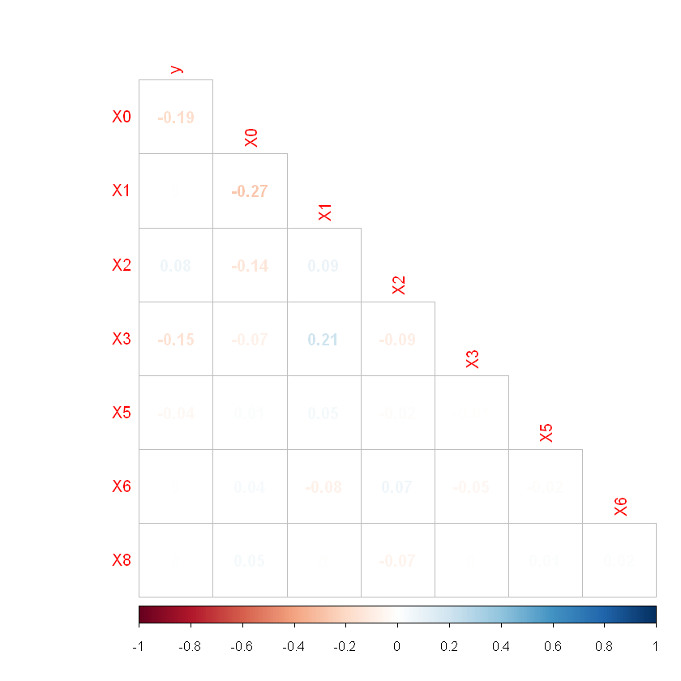

```r
train %>%
  select(y,X0:X8) %>%
  mutate_at(vars(starts_with("X")), funs(as.integer)) %>%
  cor(use="complete.obs", method="pearson") %>%
  corrplot(type="lower", method="number", diag=FALSE)
```

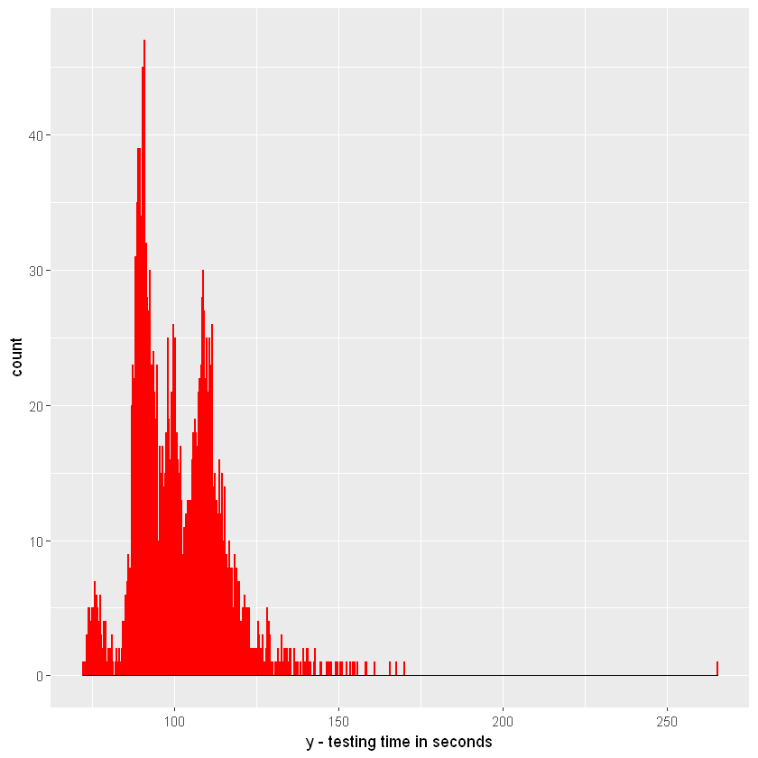

```r
train %>%
  ggplot(aes(y)) +
  geom_histogram(colour="red", bins = length(train$y)/3) +
  geom_density() +
  labs(x = "y - testing time in seconds")
```

Above is a histogram/density plot of the distribution of the target variable y- testing time in seconds. We see a couple of things from this plot above:

there is a wide variation in the units of y with what appears to be the largest value of y being greater than 250 while the lowest is less than 75 seconds.

It appears as if from this histogram/density plot above that we have one extreme observation (outlier) of the dependent variable estimated to be y=265.

Below we re-draw the distribution with these highest peaks outlined in red, to distinguish them.

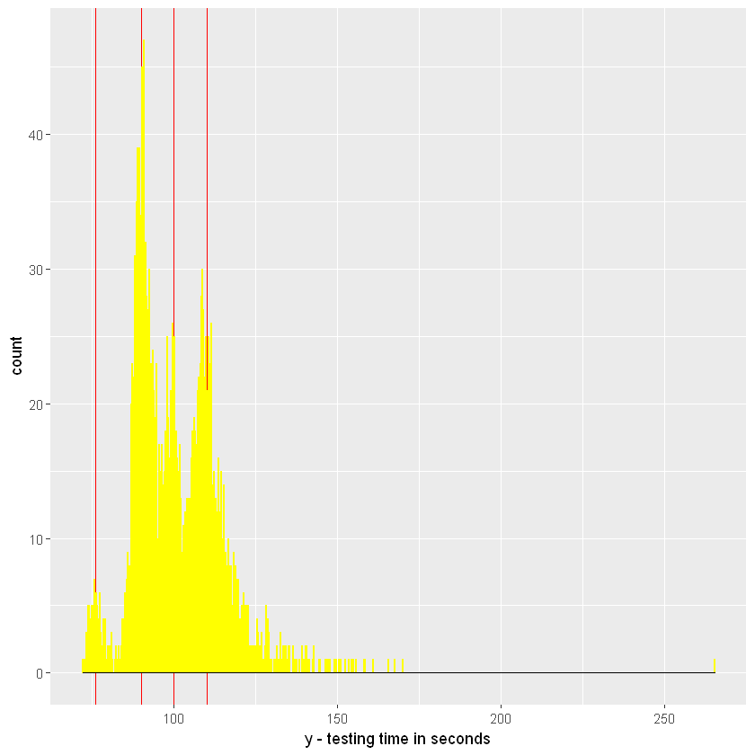

```r
train %>%
  ggplot(aes(y)) +
  geom_vline(xintercept = c(76,90,100,110), colour="red")+
  geom_histogram(colour="yellow", bins = length(train$y)/3) +
  geom_density() +
  labs(x = "y - testing time in seconds")
```

We next try to further identify key points within out plot above, to identify the key lowest points in the distribution. The key lowest points are: 1. y=80 2. y=95 3. y=105

Below we further identify the lower points of the distribution by putting blue lines at these points.

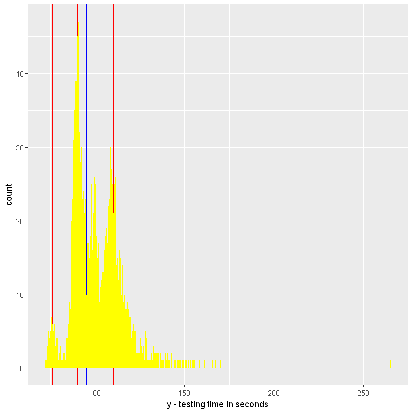

```r
train %>%
  ggplot(aes(y)) +
  geom_vline(xintercept = c(76,90,100,110), colour="red")+
  geom_vline(xintercept = c(80,95,105), colour="blue")+
  geom_histogram(colour="yellow", bins = length(train$y)/3) +
  geom_density() +
  labs(x = "y - testing time in seconds")
```

Next in order to make the x axis easier to read, but still accounting for the large time-scales of specific observations we can place a logarithmic scale on this plot. We do this in the code below.

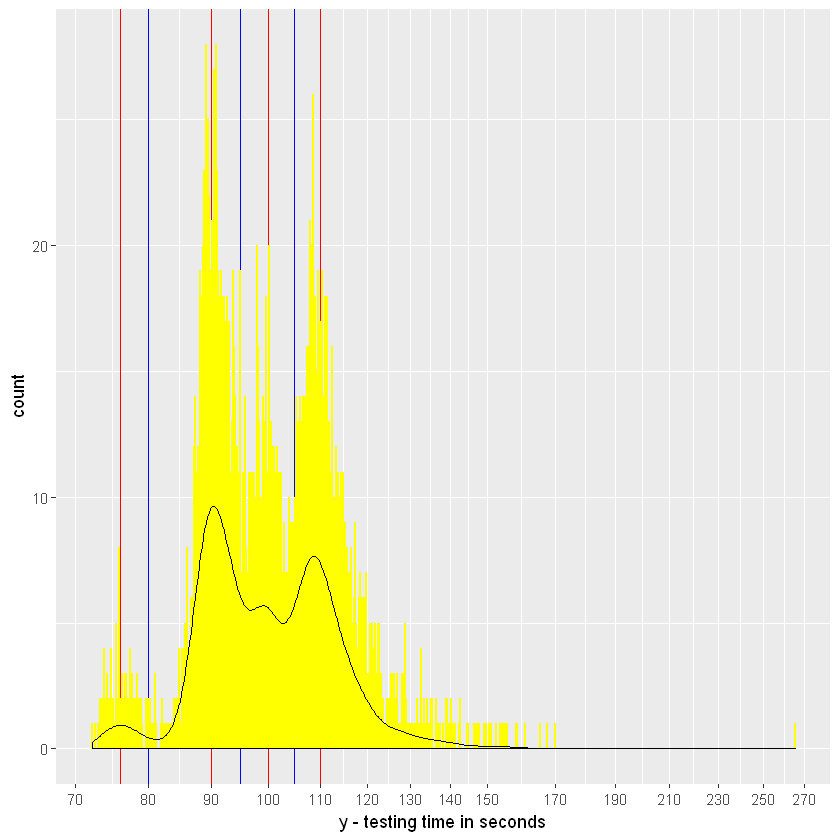

```r
train %>%
  ggplot(aes(y)) +
  geom_vline(xintercept = c(76,90,100,110), colour="red")+ #taking those 3 bins and highlighting in red the 4 main peaks of the data
  geom_vline(xintercept = c(80,95,105), colour="blue")+  #highlighting in blue the 3 lowest peaks within the binned data
  geom_histogram(colour="yellow", bins = length(train$y)/3) + #dividing the data into three bins
  geom_density() + #fitting the density
  scale_x_log10(breaks=c(seq(70,150,10),seq(170,270,20)) ) +
  labs(x = "y - testing time in seconds")
```

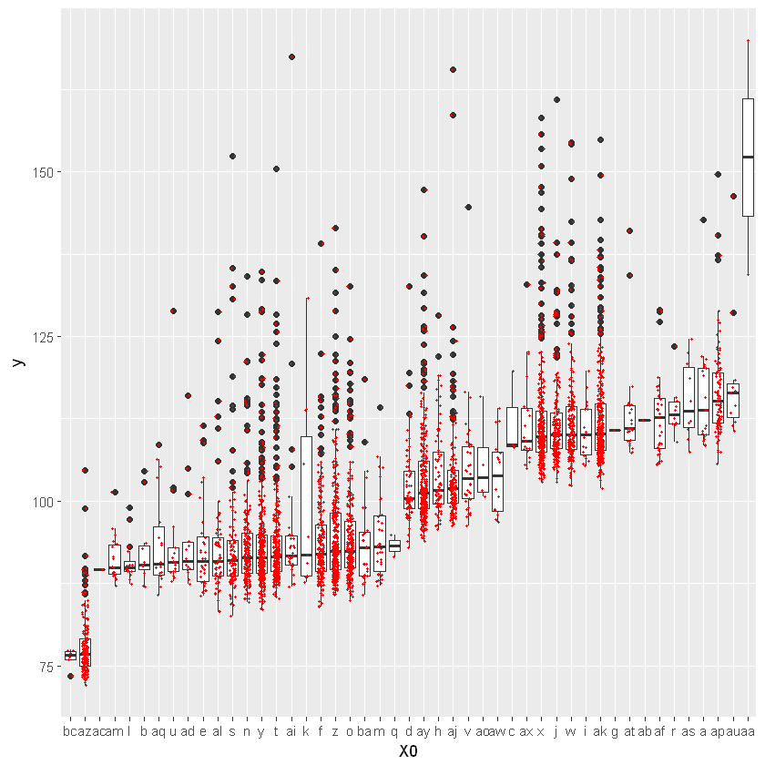

```r
train <- train %>%
  filter(y < 250)
ggplot(train, aes(reorder(X0, y, FUN = median) , y)) + geom_boxplot() + labs(x = "X0") +
  geom_jitter(color="red", width = 0.2, size = 0.4)
```

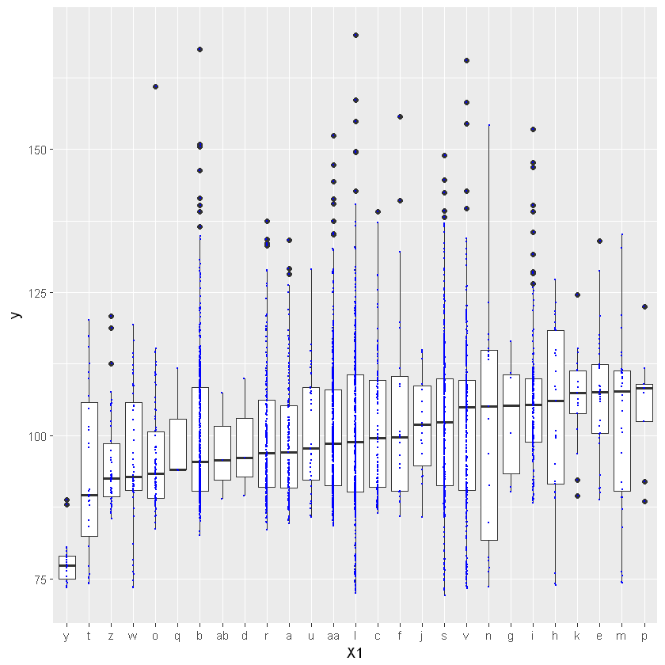

```r
ggplot(train, aes(reorder(X1, y, FUN=median), y)) +
  geom_boxplot()+
  labs(x="X1")+
  geom_jitter(color='blue', width=.02, size=.04)
```

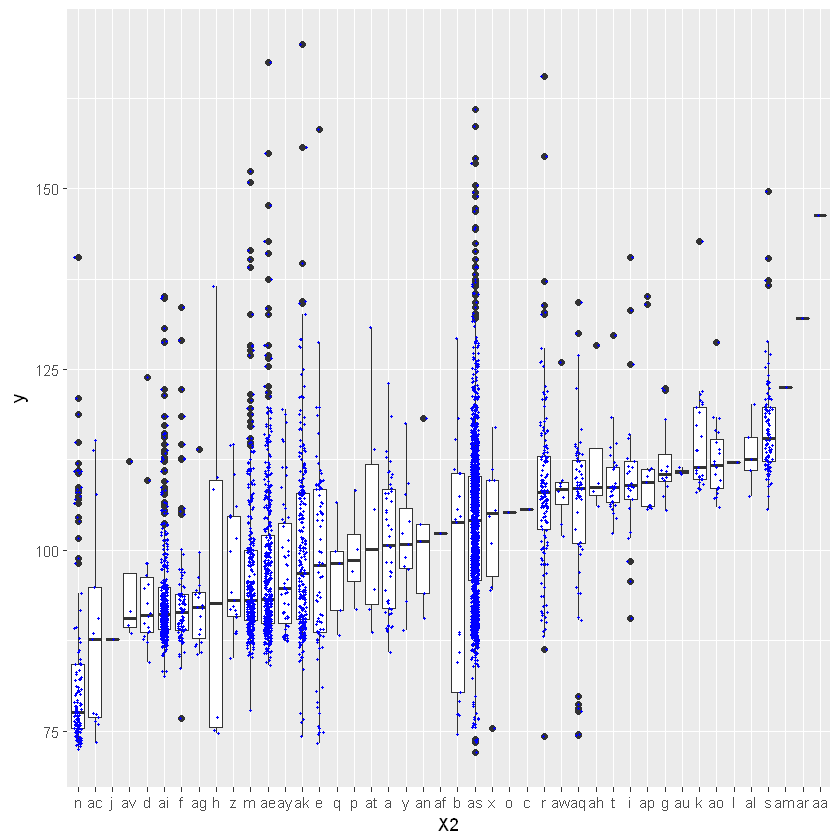

```r
ggplot(train, aes(reorder(X2, y, FUN=median), y))+
  geom_boxplot()+
  labs(x="X2")+
  geom_jitter(color="blue", width=.2, size=.4)
```

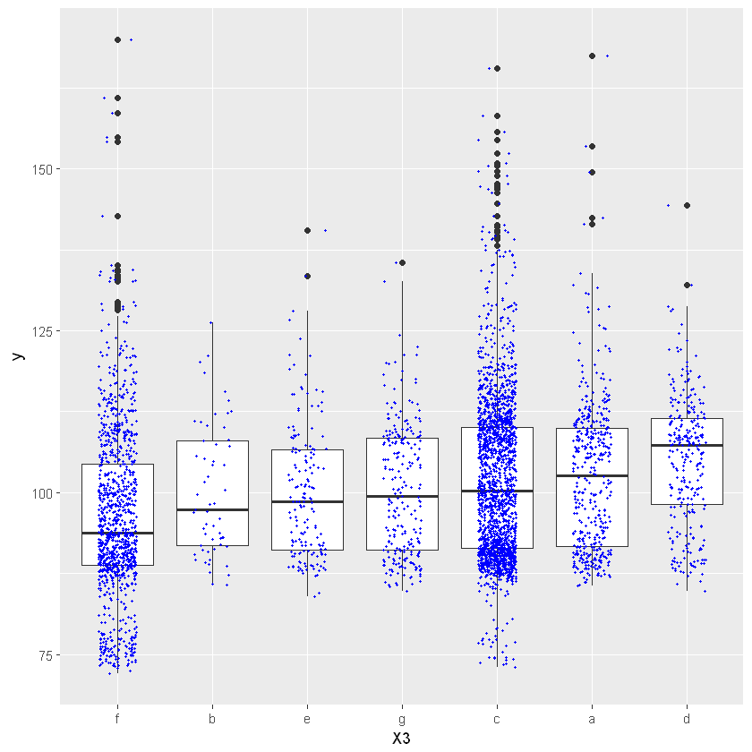

```r
ggplot(train, aes(reorder(X3, y, FUN=median),y)) +
  geom_boxplot() +
  labs(x="X3")+
  geom_jitter(color="blue", width=.2, size=.4)
```

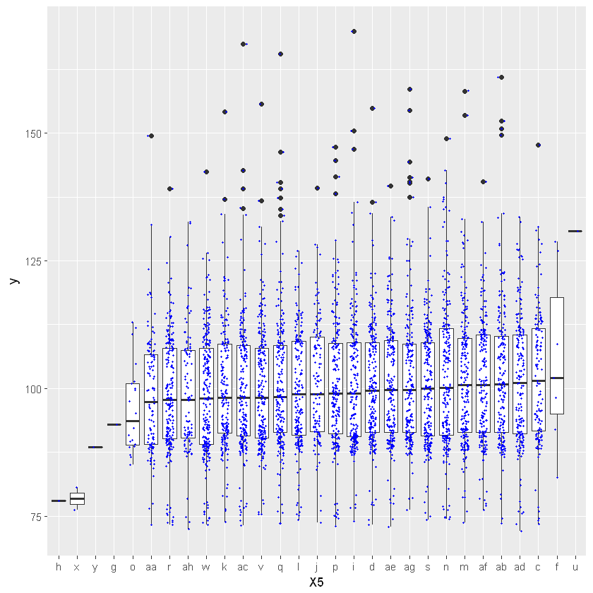

```r
ggplot(train, aes(reorder(X5, y, FUN=median),y)) +
  geom_boxplot() +
  labs(x="X5")+
  geom_jitter(color="blue", width=.2, size=.4)
```

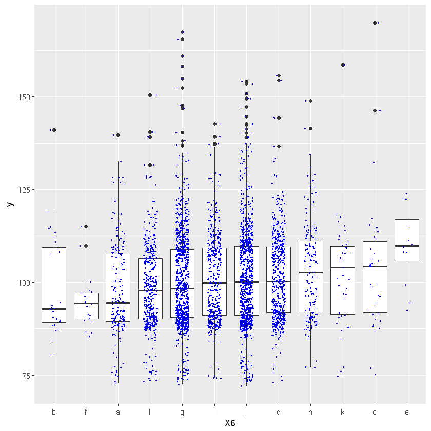

```r
ggplot(train, aes(reorder(X6, y, FUN=median),y)) +
  geom_boxplot() +
  labs(x="X6")+
  geom_jitter(color="blue", width=.2, size=.4)
```

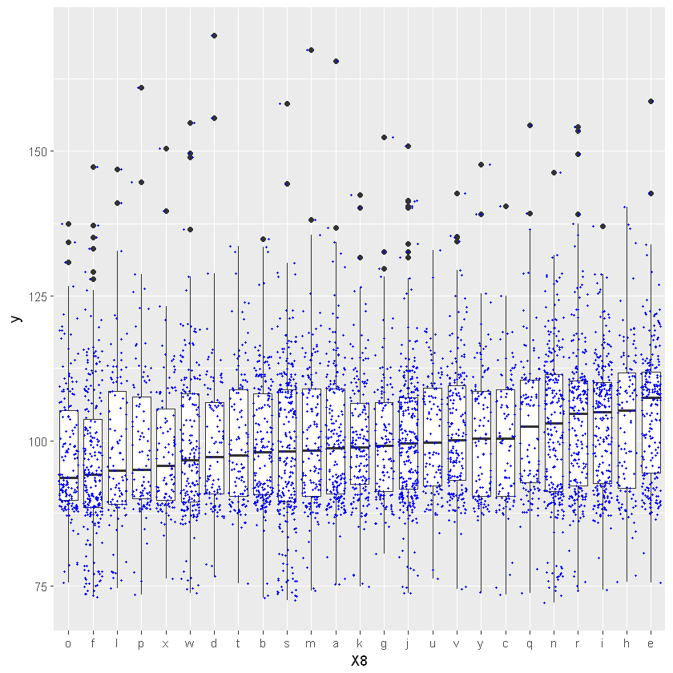

```r
ggplot(train, aes(reorder(X8, y, FUN=median),y)) +
  geom_boxplot() +
  labs(x="X8")+
  geom_jitter(color="blue", width=.4, size=.6)
```

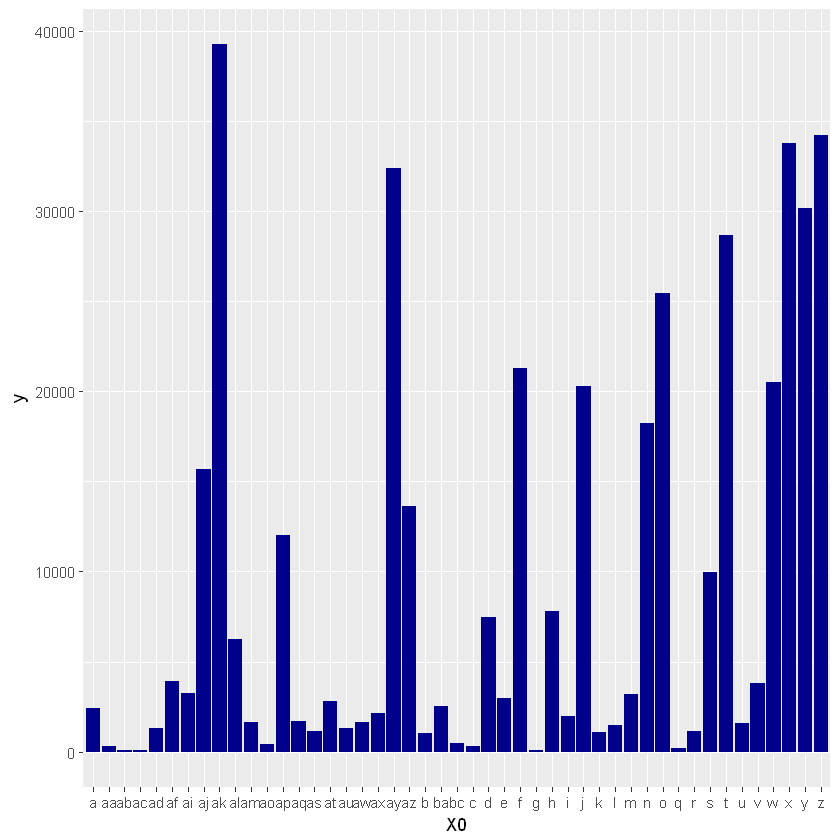

```r
ggplot(train, aes(X0, y))+ geom_bar(stat="identity", fill="darkblue") + scale_x_discrete("X0")
```

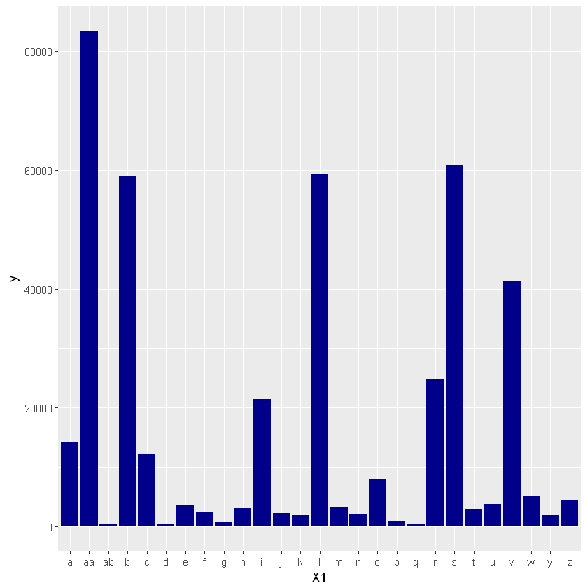

```r
ggplot(train, aes(X1, y))+ geom_bar(stat="identity", fill="darkblue") + scale_x_discrete("X1")
```

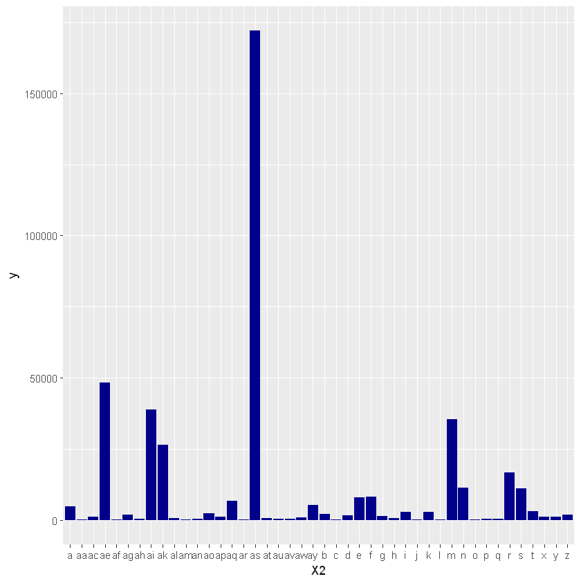

```r
ggplot(train, aes(X2, y))+ geom_bar(stat="identity", fill="darkblue") + scale_x_discrete("X2")
```

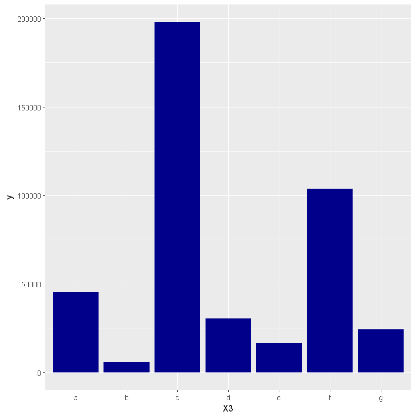

```r
ggplot(train, aes(X3, y))+ geom_bar(stat="identity", fill="darkblue") + scale_x_discrete("X3")
```

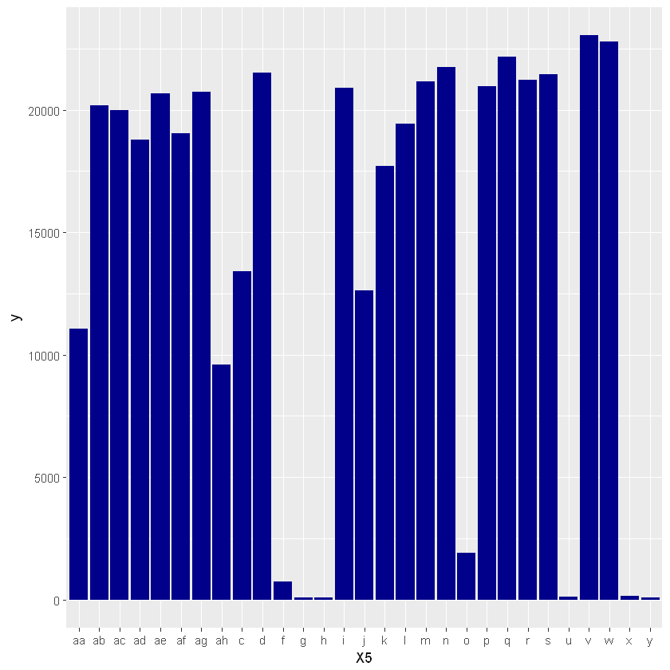

```r
ggplot(train, aes(X5, y))+ geom_bar(stat="identity", fill="darkblue") + scale_x_discrete("X5")
```

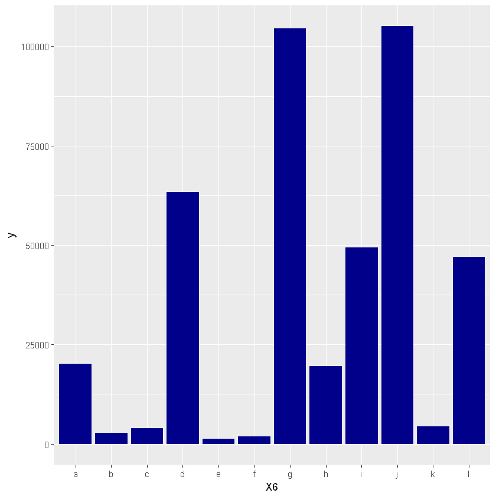

```r
ggplot(train, aes(X6, y))+ geom_bar(stat="identity", fill="darkblue") + scale_x_discrete("X6")
```

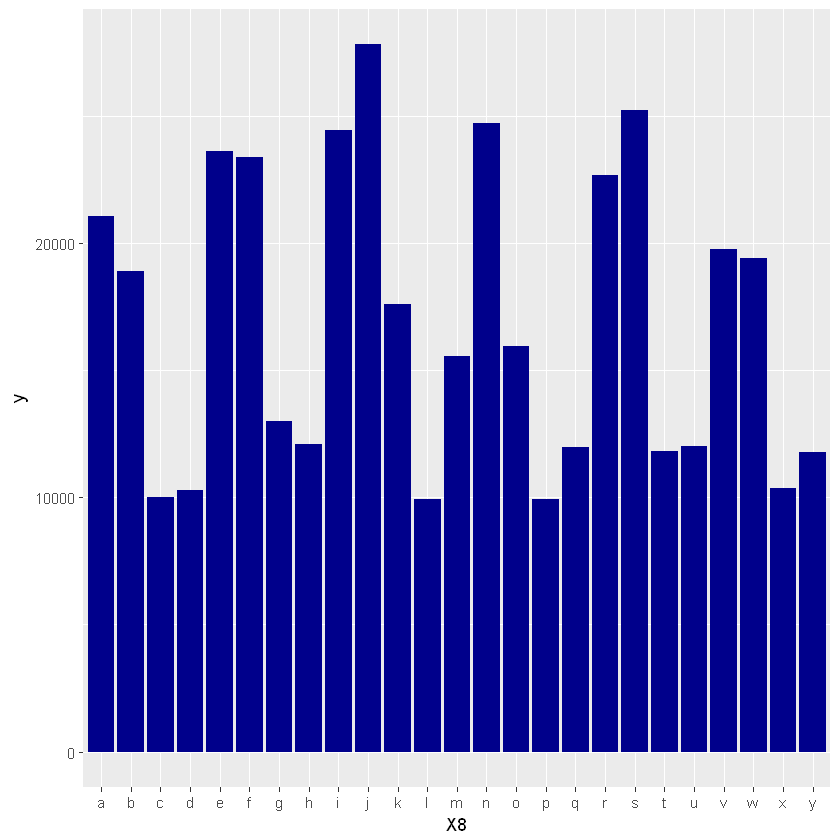

```r
ggplot(train, aes(X8, y))+ geom_bar(stat="identity", fill="darkblue") + scale_x_discrete("X8")
```

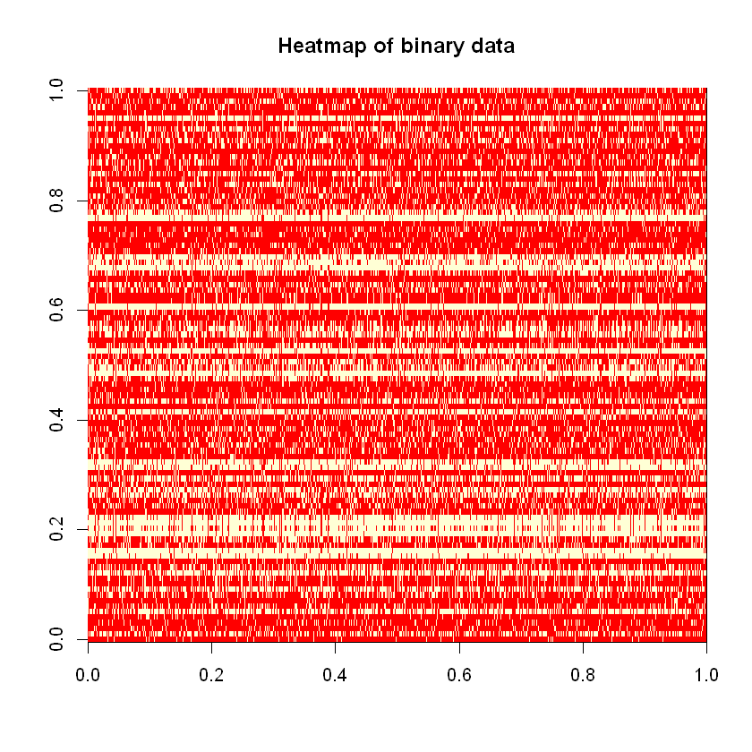

```r
train <- read.csv("C:/Users/betha/Desktop/EXST_7152/Group_Project/clean_train.csv")
test <- read.csv("C:/Users/betha/Desktop/EXST_7152/Group_Project/clean_test.csv")
full <- read.csv("C:/Users/betha/Desktop/EXST_7152/Group_Project/clean_full.csv")
#removing multicolinearity
require(corrplot)
t <- cor(train[,-c(1,3:10)])
highlyCorrelation <- findCorrelation(t,cutoff = 0.95, names = T)

train[,highlyCorrelation] <- NULL
test[,highlyCorrelation] <- NULL
image(as.matrix(train[,-c(1:10)]), main="Heatmap of binary data")
```

# MODELING PHASE

```r
library('ggplot2') # visualization
library('ggthemes') # visualization
library('scales') # visualization
library('grid') # visualisation
library('gridExtra') # visualisation
library('corrplot') # visualisation
library('dplyr') # data manipulation
library('readr') # data input
library('tibble') # data wrangling
library('stringr') # string manipulation
library('forcats') # factor manipulation
library('mclust') # clustering
library(pls) #partial least squares
library("rstan")
library("caret")
library(glmnet)
library(lars)
```

```r
train$X <- NULL
train$X0 <- NULL
train$X2 <- NULL
train$X5 <- NULL

test$X <- NULL
test$X0 <- NULL
test$X2 <- NULL
test$X5 <- NULL
str(test)
```

```
'data.frame':	4209 obs. of  106 variables:
 $ y   : int  0 0 0 0 0 0 0 0 0 0 ...
 $ X1  : Factor w/ 27 levels "a","aa","ab",..: 24 4 24 14 21 2 4 21 14 24 ...
 $ X3  : Factor w/ 7 levels "a","b","c","d",..: 6 1 6 6 3 5 4 3 3 6 ...
 $ X6  : Factor w/ 12 levels "a","b","c","d",..: 1 7 10 12 9 7 4 4 10 6 ...
 $ X8  : Factor w/ 25 levels "a","b","c","d",..: 23 25 10 14 13 19 25 1 14 22 ...
 $ X12 : int  0 0 0 0 0 0 0 0 0 0 ...
 $ X13 : int  0 0 0 0 0 0 0 1 0 0 ...
 $ X14 : int  0 0 1 0 1 0 0 0 0 1 ...
 $ X19 : int  0 1 0 0 0 1 0 0 0 0 ...
 $ X20 : int  0 0 0 0 0 0 1 1 0 0 ...
 $ X22 : int  0 0 0 0 0 0 0 0 0 0 ...
 $ X27 : int  1 1 1 1 1 1 1 0 0 0 ...
 $ X37 : int  1 1 1 1 0 1 0 0 1 0 ...
 $ X43 : int  1 0 0 1 0 0 0 0 0 0 ...
```

[output cut: 86 more lines]

Preparing data for ridge,lasso,pls models

```r
X<- model.matrix(y~., train)[,-1]


X_test <- model.matrix(y~., test)[,-1]

y <- train$y
dim(X)
```

1. 4209

2. 168

```r
dim(X_test)
```

1. 4209

2. 168

```r
print(X_test)
```

[output not shown]

[output cut: 6542 more lines]

## RIDGE REGRESSION

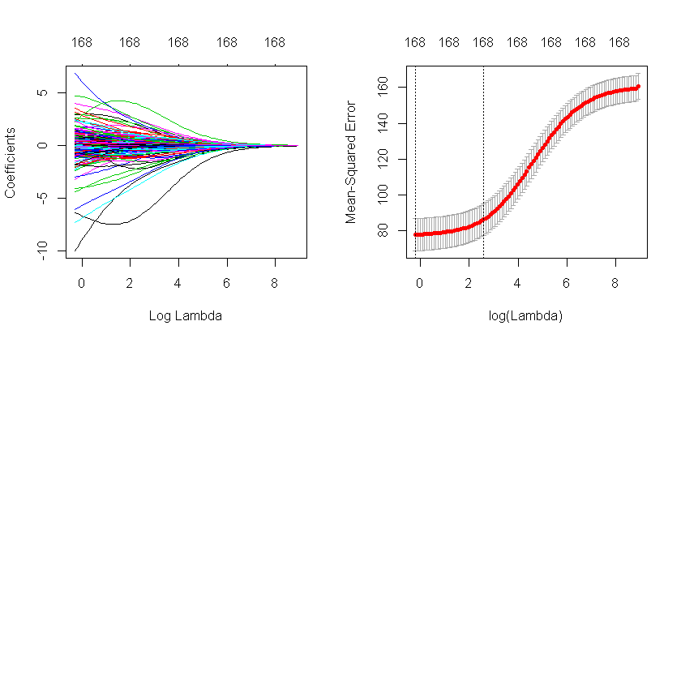

```r
fit.ridge.full <- glmnet(X, y, alpha=0)
cv.ridge = cv.glmnet(X,y, alpha=0)

par(mfrow=c(2,2))
plot(fit.ridge.full, xvar="lambda", label=TRUE)
plot(cv.ridge)
```

```r
bestlam.ridge=cv.ridge$lambda.min #Getting lambda that gives smallest MSE
bestlam.ridge
```

0.819232854451133

```r
ridge.predict= predict(cv.ridge,type="coefficients", s=bestlam.ridge, newx = X_test)
ridge.Yhat <- predict(fit.ridge.full, type="response", s=bestlam.ridge, newx=X_test)
```

Calculating Ridge Model Fit Statistics

```r
ridge.R2 <- function(Y,R.Yhat){
  R2 <- (abs(1 - (sum((Y-R.Yhat)^2)/sum((Y-mean(Y))^2))))
  return(R2)
}
ridge.MSE <- function(Y,R.Yhat){
  return(mean((R.Yhat-(mean(Y)))^2))
}
ridge.SSE <- function(Y, R.Yhat){
  SSE <- (sum((Y-R.Yhat)^2))
  return(SSE)
}
ridge.SSR <- function(Y, R.Yhat){
  SSR <- (sum((R.Yhat- (mean(Y)))^2))
  return(SSR)
}
ridge.SSTO <- function(Y, R.Yhat){
  SSTO <- (sum((Y- (mean(R.Yhat)))^2))
  return(SSTO)
}
```

```r
print('Ridge r2 score')
ridge.R2(y, ridge.Yhat)
print('Ridge MSE')
ridge.MSE(y,ridge.Yhat)
print('Ridge SSE')
ridge.SSE(y,ridge.Yhat)
print('Ridge SSR')
ridge.SSR(y,ridge.Yhat)
print('Ridge SSTO')
ridge.SSTO(y,ridge.Yhat)
```

```
[1] "Ridge r2 score"
```

0.523524247684034

```
[1] "Ridge MSE"
```

82.1817568019604

```
[1] "Ridge SSE"
```

1030673.77361296

```
[1] "Ridge SSR"
```

345903.014379451

```
[1] "Ridge SSTO"
```

676825.99097972

## LASSO REGRESSION

Performing Lasso Cross Validation in order to get best lambda that provides the minimum mean squared error for model fit

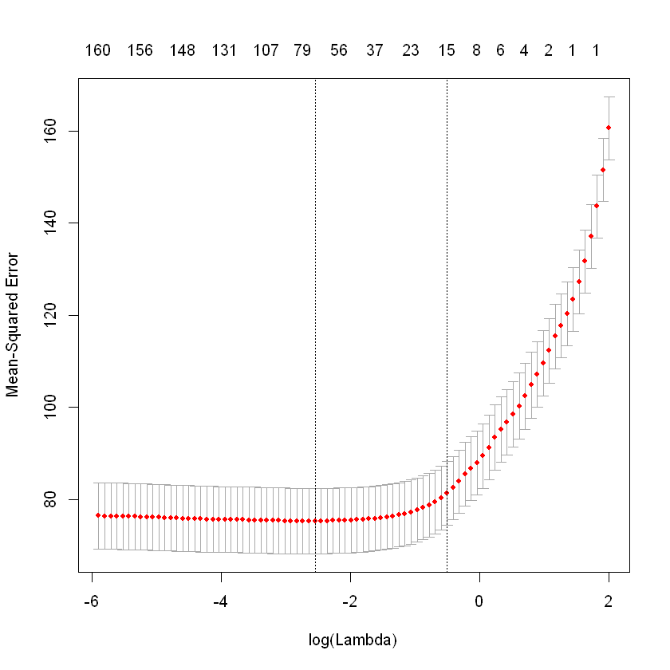

```r
lasso.cv.glm <- cv.glmnet(X, y, nfolds=10, type.measure="mse", alpha=1)
plot(lasso.cv.glm)
```

```r
lasso.cv.glm$lambda.min #value of lambda that gives us minimum MSE
```

0.0781997456862997

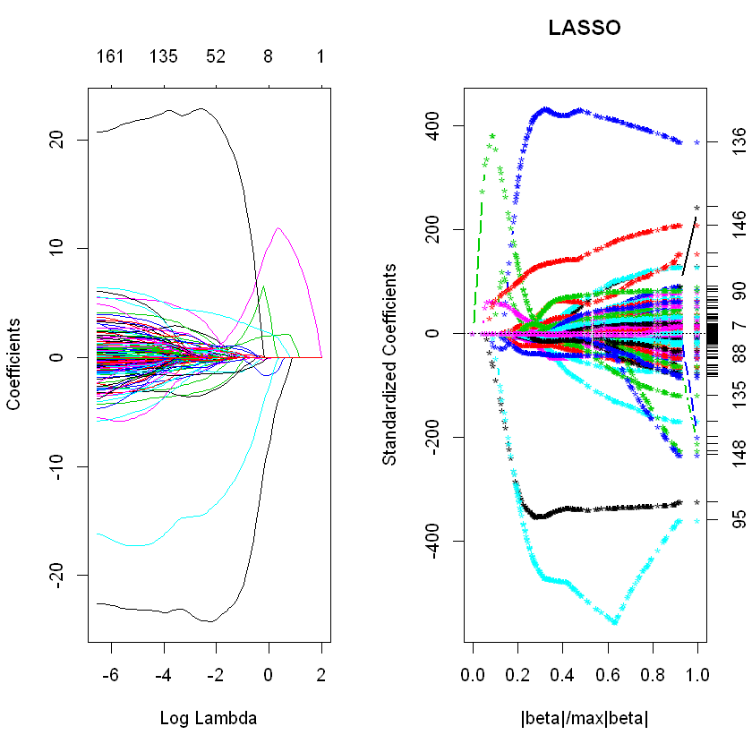

```r
lasso.fit <- lars(X,y,type="lasso")
fit.lasso.full <- glmnet(X, y, alpha=1)
par(mfrow=c(1,2))
plot(fit.lasso.full, xvar="lambda", label=TRUE)
plot(lasso.fit, lwd=2, breaks=F)
```

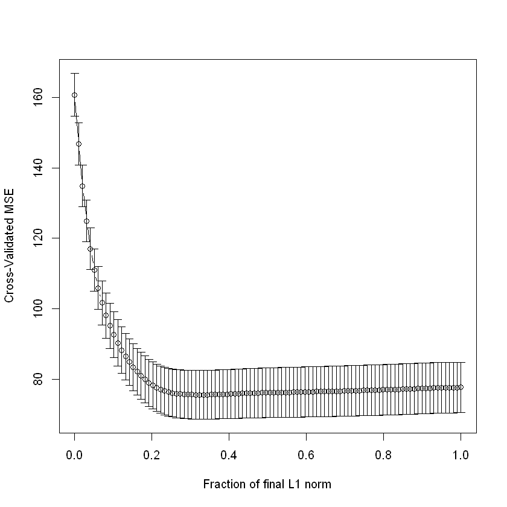

```r
lasso.cv <- cv.lars(X, y, K=10, trace=F, plot.it=T, se=T, type="lasso")
```

```r
op.frac.lasso <- lasso.cv$index[which.min(lasso.cv$cv)]
op.frac.lasso
```

0.333333333333333

Below we display the variables selected using the lasso model along with the coefficients for each variables

```r
beta <- predict(lasso.fit, X_test, s=op.frac.lasso,type="coef", mode="fraction")$coef
beta[beta !=0]
```

**X1f**

2.26412780145643

**X1h**

2.10704866153038

**X1l**

0.525219335745723

**X1m**

-0.123516719177585

**X1n**

0.999569671489191

**X1p**

-0.383839044583413

**X1q**

-1.01670370087676

**X1r**

0.745404619826412

**X1t**

-3.15366881233042

**X1u**

-1.38233302383865

**X1v**

-0.237143995245199

**X1w**

-0.0905212049858708

**X1y**

-3.55873557987717

**X3b**

-2.09297878586158

**X3c**

0.758607987482653

**X6c**

0.951875453904645

**X6d**

-0.0454597108834811

**X6e**

3.60070852130306

**X6g**

0.249534876494977

**X6h**

0.423177592447414

**X6j**

0.58439236139617

**X8c**

0.369832908780062

**X8d**

-0.551305203214301

**X8f**

-0.00188220621972135

**X8g**

-0.540561253872939

**X8i**

-0.530760395360293

**X8l**

-0.0234604465623189

**X8p**

0.219973059655669

**X8r**

0.535752122211014

**X8s**

-0.167698441829866

**X8t**

1.25696462749117

**X8u**

-0.863799633531172

**X12**

0.873510823095537

**X19**

-0.117700965415312

**X45**

-0.970698542222714

**X51**

0.00899678314533242

**X64**

-0.199001415915929

**X80**

-23.990999376411

**X81**

-0.300197609379975

**X114**

-0.126937091020747

**X127**

-14.5164936179629

**X132**

-1.3369081056915

**X137**

0.754939482724432

**X144**

0.0424708342464447

**X150**

-1.00891119243565

**X151**

0.842791695125593

**X157**

-0.219996190823492

**X163**

-0.467516525510656

**X171**

0.0109024025277144

**X177**

0.167463559329343

**X180**

0.512607521335294

**X181**

0.134301889200152

**X187**

1.66153783304527

**X209**

0.520832700480514

**X220**

-0.34452349642685

**X225**

-0.0948411672308995

**X244**

1.30758470483436

**X256**

-1.25104244232449

**X265**

22.7525056154472

**X275**

0.662125322076691

**X301**

1.40588276489649

**X304**

-0.432276644452314

**X311**

4.27820787235544

**X316**

-1.52396248605088

**X327**

0.10746669911712

**X337**

0.0872479911958519

**X350**

-0.203759696478016

**X351**

-0.0235265850420623

**X352**

-0.906745812558023

**X355**

1.66935788072134

**X360**

0.0524422287256664

**X368**

1.54254880549738

**X374**

0.491907862807804

**X376**

0.0359300516667345

```r
y.pred <- predict(lasso.fit,X_test, s=op.frac.lasso, type="fit", mode="fraction")$fit
```

Calculating the Lasso Model Fit statistics

```r
lasso.R2 <- function(Y,Yhat){
  R2 <- (abs(1 - (sum((Y-Yhat)^2)/sum((Y-mean(Y))^2))))
  return(R2)
}
lasso.MSE <- function(Y,Yhat){
  return(mean((Yhat-(mean(Y)))^2))
}
lasso.SSE <- function(Y, Yhat){
  SSE <- (sum((Y-Yhat)^2))
  return(SSE)
}
lasso.SSR <- function(Y, Yhat){
  SSR <- (sum((Yhat- (mean(Y)))^2))
  return(SSR)
}
lasso.SSTO <- function(Y, Yhat){
  SSTO <- (sum((Y- (mean(Yhat)))^2))
  return(SSTO)
}
```

```r
print('Lasso r2 score')
lasso.R2(y, y.pred)
print('Lasso MSE')
lasso.MSE(y,y.pred)
print('Lasso SSE')
lasso.SSE(y,y.pred)
print('Lasso SSR')
lasso.SSR(y,y.pred)
print('Lasso SSTO')
lasso.SSTO(y,y.pred)
```

```
[1] "Lasso r2 score"
```

0.540339568032526

```
[1] "Lasso MSE"
```

84.4522456798675

```
[1] "Lasso SSE"
```

1042049.44400641

```
[1] "Lasso SSR"
```

355459.502066562

```
[1] "Lasso SSTO"
```

676787.673928176

## Partial Least Squares Model

```r
pls.fit = plsr(y~., data=train, scale=TRUE, validation="CV") #fitting the model via. cross validation
summary(pls.fit)
```

```
Data: 	X dimension: 4209 168
	Y dimension: 4209 1
Fit method: kernelpls
Number of components considered: 168

VALIDATION: RMSEP
Cross-validated using 10 random segments.
       (Intercept)  1 comps  2 comps  3 comps  4 comps  5 comps  6 comps
CV           12.68    10.31    9.438    9.126    9.006    8.966    8.954
adjCV        12.68    10.31    9.435    9.120    8.998    8.955    8.940
       7 comps  8 comps  9 comps  10 comps  11 comps  12 comps  13 comps
CV       8.949    8.938    8.917     8.892     8.855     8.834     8.824
adjCV    8.932    8.919    8.897     8.872     8.835     8.814     8.804
       14 comps  15 comps  16 comps  17 comps  18 comps  19 comps  20 comps
CV        8.820     8.812     8.797      8.78     8.772     8.769     8.768
adjCV     8.798     8.790     8.775      8.76     8.753     8.750     8.748
       21 comps  22 comps  23 comps  24 comps  25 comps  26 comps  27 comps
CV        8.767     8.763     8.762     8.764     8.769      8.77     8.769
adjCV     8.747     8.743     8.743     8.744     8.748      8.75     8.748
       28 comps  29 comps  30 comps  31 comps  32 comps  33 comps  34 comps
CV        8.770     8.775     8.773     8.771     8.771     8.772     8.772
adjCV     8.749     8.753     8.752     8.750     8.751     8.751     8.751
       35 comps  36 comps  37 comps  38 comps  39 comps  40 comps  41 comps
CV        8.772     8.773     8.775     8.775     8.776     8.778     8.779
adjCV     8.751     8.752     8.754     8.754     8.755     8.757     8.758
       42 comps  43 comps  44 comps  45 comps  46 comps  47 comps  48 comps
CV        8.780     8.781     8.783     8.784     8.786     8.787     8.788
adjCV     8.759     8.759     8.761     8.763     8.765     8.765     8.766
       49 comps  50 comps  51 comps  52 comps  53 comps  54 comps  55 comps
CV        8.790     8.791     8.793     8.795     8.795     8.797     8.798
adjCV     8.768     8.769     8.771     8.772     8.773     8.774     8.775
       56 comps  57 comps  58 comps  59 comps  60 comps  61 comps  62 comps
CV        8.798     8.799     8.800     8.800     8.801     8.801     8.801
adjCV     8.776     8.776     8.777     8.777     8.778     8.778     8.778
       63 comps  64 comps  65 comps  66 comps  67 comps  68 comps  69 comps
CV        8.801     8.801     8.802     8.802     8.803     8.803     8.804
adjCV     8.778     8.779     8.779     8.779     8.780     8.780     8.781
       70 comps  71 comps  72 comps  73 comps  74 comps  75 comps  76 comps
CV        8.804     8.804     8.804     8.804     8.804     8.805     8.805
adjCV     8.781     8.781     8.781     8.781     8.781     8.781     8.782
```

[output cut: 104 more lines]

```
   135 comps  136 comps  137 comps  138 comps  139 comps  140 comps  141 comps
X      93.68      93.94      94.30      94.54      94.93      95.09      95.55
y      56.34      56.34      56.34      56.34      56.34      56.34      56.34
   142 comps  143 comps  144 comps  145 comps  146 comps  147 comps  148 comps
X      95.85      96.19      96.33      96.82      96.93      97.42      97.52
y      56.34      56.34      56.34      56.34      56.34      56.34      56.34
   149 comps  150 comps  151 comps  152 comps  153 comps  154 comps  155 comps
X      97.96      98.17      98.56      98.83      98.99      99.49      99.55
y      56.34      56.34      56.34      56.34      56.34      56.34      56.34
   156 comps  157 comps  158 comps  159 comps  160 comps  161 comps  162 comps
X      99.61      99.67      99.71      99.76      99.82      99.84      99.87
y      56.34      56.34      56.34      56.34      56.34      56.34      56.34
   163 comps  164 comps  165 comps  166 comps  167 comps  168 comps
X      99.90      99.92      99.95      99.97     100.00     100.05
y      56.34      56.34      56.34      56.34      56.34      56.34
```

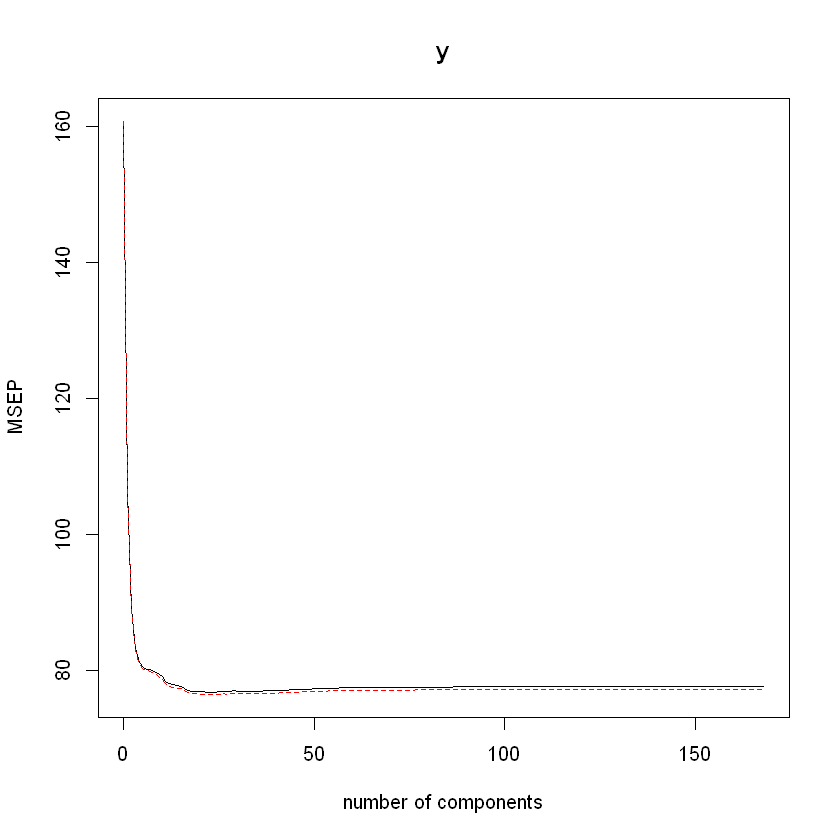

```r
validationplot(pls.fit, val.type = "MSEP")
```

Using model fit with optimal number of principal components to predict Y on Test data

```r
plsYhat=predict(pls.fit,X_test,ncomp = 23)
```

Calculating Partial Least Squares Predicted Model Fit Statistics

```r
PLS.R2 <- function(Y,Yhat){
  R2 <- (abs(1 - (sum((Y-Yhat)^2)/sum((Y-mean(Y))^2))))
  return(R2)
}
PLS.MSE <- function(Y,Yhat){
  return(mean((Yhat-(mean(Y)))^2))
}
PLS.SSE <- function(Y, Yhat){
  SSE <- (sum((Y-Yhat)^2))
  return(SSE)
}
PLS.SSR <- function(Y, Yhat){
  SSR <- (sum((Yhat- (mean(Y)))^2))
  return(SSR)
}
PLS.SSTO <- function(Y, Yhat){
  SSTO <- (sum((Y- (mean(Yhat)))^2))
  return(SSTO)
}
```

```r
print('PLS r2 score')
PLS.R2(y, plsYhat)
print('PLS MSE score')
PLS.MSE(y, plsYhat)
print('PLS SSE score')
PLS.SSE(y, plsYhat)
print('PLS SSR score')
PLS.SSR(y, plsYhat)
print('PLS SSTO score')
PLS.SSTO(y, plsYhat)
```

```
[1] "PLS r2 score"
```

0.581328500481693

```
[1] "PLS MSE score"
```

90.7956017445594

```
[1] "PLS SSE score"
```

1069778.71562646

```
[1] "PLS SSR score"
```

382158.687742851

```
[1] "PLS SSTO score"
```

676907.950400015